# Machine Learning Project

# Background

#### Using devices such as Jawbone Up, Nike FuelBand, and Fitbit it is now possible to collect a large amount of data about personal activity relatively inexpensively. These type of devices are part of the quantified self movement - a group of enthusiasts who take measurements about themselves regularly to improve their health, to find patterns in their behavior, or because they are tech geeks. One thing that people regularly do is quantify how much of a particular activity they do, but they rarely quantify how well they do it. In this project, your goal will be to use data from accelerometers on the belt, forearm, arm, and dumbell of 6 participants. They were asked to perform barbell lifts correctly and incorrectly in 5 different ways.

# Data Exploration and Processing

```r
# Set working directory and load required packages
setwd("C:/Users/bkindle/Desktop/Data Science/8 - Machine Learning/Project")
library(caret)
library(knitr)
library(randomForest)
library(doParallel)
# Import training data set
main_train <- read.csv("pml-training.csv",na.strings = c("NA",""))

# Review the data, take out the first 7 columns which are not
# relevant to the outcome
str(main_train)
```

```
## 'data.frame':    19622 obs. of  160 variables:
##  $ X                       : int  1 2 3 4 5 6 7 8 9 10 ...
##  $ user_name               : Factor w/ 6 levels "adelmo","carlitos",..: 2 2 2 2 2 2 2 2 2 2 ...
##  $ raw_timestamp_part_1    : int  1323084231 1323084231 1323084231 1323084232 1323084232 1323084232 1323084232 1323084232 1323084232 1323084232 ...
##  $ raw_timestamp_part_2    : int  788290 808298 820366 120339 196328 304277 368296 440390 484323 484434 ...
##  $ cvtd_timestamp          : Factor w/ 20 levels "02/12/2011 13:32",..: 9 9 9 9 9 9 9 9 9 9 ...
##  $ new_window              : Factor w/ 2 levels "no","yes": 1 1 1 1 1 1 1 1 1 1 ...
##  $ num_window              : int  11 11 11 12 12 12 12 12 12 12 ...
##  $ roll_belt               : num  1.41 1.41 1.42 1.48 1.48 1.45 1.42 1.42 1.43 1.45 ...
##  $ pitch_belt              : num  8.07 8.07 8.07 8.05 8.07 8.06 8.09 8.13 8.16 8.17 ...
##  $ yaw_belt                : num  -94.4 -94.4 -94.4 -94.4 -94.4 -94.4 -94.4 -94.4 -94.4 -94.4 ...
##  $ total_accel_belt        : int  3 3 3 3 3 3 3 3 3 3 ...
##  $ kurtosis_roll_belt      : Factor w/ 396 levels "-0.016850","-0.021024",..: NA NA NA NA NA NA NA NA NA NA ...
##  $ kurtosis_picth_belt     : Factor w/ 316 levels "-0.021887","-0.060755",..: NA NA NA NA NA NA NA NA NA NA ...
##  $ kurtosis_yaw_belt       : Factor w/ 1 level "#DIV/0!": NA NA NA NA NA NA NA NA NA NA ...
```

[output cut: 86 more lines]

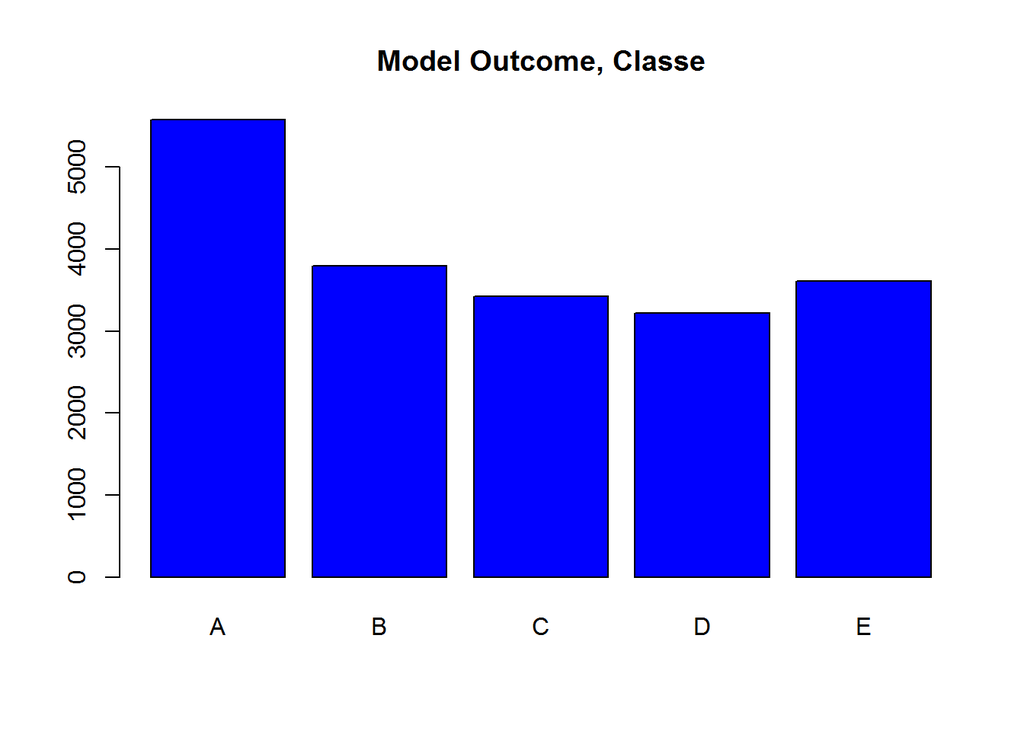

```r
main_train <- main_train[,-c(1:7)]
main_train_obs  <- dim(main_train)[1]
main_train_vars <- dim(main_train)[2]
barplot(table(main_train$classe),main="Model Outcome, Classe", col="blue")
```

```r
# Test for NA values, exclude variables that are over 95% NA
na_subset <- c()
for (i in 1:main_train_vars) {
na_subset[i] <- ifelse(((sum(is.na(main_train[,i]))/NROW(main_train[,i]))*100)>95,TRUE,FALSE)
}
main_train_short <- main_train[,!na_subset]
main_train_short <- main_train_short[sample(nrow(main_train_short),10000),]
mts_cols <- dim(main_train_short)[2]
```

# Model Selection and Training

#### Cross Validation involves estimating test set accuracy and out of sample error by splitting the training data set into sub-training and sub-testing sets (i.e. via random subsampling, k-fold, leave one out, etc). This process allows one to detect relevant predictors/features as well as an appropriate model function.

```r
# Split main_train into sub_train and sub_test
set.seed(1)
sub_split <- createDataPartition(y=main_train_short$classe, p=0.7, list=FALSE)
sub_train <- main_train_short[sub_split,]
sub_test <- main_train_short[-sub_split,]
```

#### Our first model type will be the random forest. This is a good candidate because our outcome is a factor variable and random forests have a reputation for accuracy. If we find that the expected out of sample error produced by this model is high, we will try another method such as boosting.

```r
# Initiate parallel processing to make the project run faster
cl <- makeCluster(detectCores())
registerDoParallel(cl)

# Define a few controls to specify how to train the model
controls <- trainControl(method="cv", number = 6)

# train the model
random_forest_model_fit <- train(classe~.,data=sub_train,
method="rf",prox=TRUE,trControl = controls,allowParallel = TRUE)

# Use our model fit on sub_train data to predict classe values in sub_test
predict_sub_test <- predict(random_forest_model_fit,sub_test)

# Confusion matrix to evaluate model accuracy and estimate out of sample error
confusionMatrix(predict_sub_test,sub_test$classe)
```

```
## Confusion Matrix and Statistics
##
##           Reference
## Prediction   A   B   C   D   E
##          A 850   7   0   0   0
##          B   1 572   8   0   2
##          C   1  10 520   7   3
##          D   0   0   4 474   5
##          E   0   0   0   0 533
##
## Overall Statistics
##
##                Accuracy : 0.984
##                  95% CI : (0.9788, 0.9882)
##     No Information Rate : 0.2843
##     P-Value [Acc > NIR] : < 2.2e-16
##
##                   Kappa : 0.9797
##  Mcnemar's Test P-Value : NA
##
## Statistics by Class:
##
##                      Class: A Class: B Class: C Class: D Class: E
## Sensitivity            0.9977   0.9711   0.9774   0.9854   0.9816
## Specificity            0.9967   0.9954   0.9915   0.9964   1.0000
## Pos Pred Value         0.9918   0.9811   0.9612   0.9814   1.0000
## Neg Pred Value         0.9991   0.9930   0.9951   0.9972   0.9959
## Prevalence             0.2843   0.1965   0.1775   0.1605   0.1812
## Detection Rate         0.2836   0.1909   0.1735   0.1582   0.1778
## Detection Prevalence   0.2860   0.1945   0.1805   0.1612   0.1778
## Balanced Accuracy      0.9972   0.9833   0.9845   0.9909   0.9908
```

```r
stopCluster(cl)
```

#### The confusion matrix shows that our random forest model fit is highly accurate. Next we will import the main testing set and use our cross validated random forest model to predict its classe values.

```r
# Use our cross-validated model to predict classe values in main_test (aka validation)
main_test <- read.csv("pml-testing.csv")
predict_main_test <- predict(random_forest_model_fit,main_test)
summary(predict_main_test)
```

```
## A B C D E
## 7 8 1 1 3
```

```r
print(predict_main_test)
```

```
##  [1] B A B A A E D B A A B C B A E E A B B B
## Levels: A B C D E
```